# bivalency_analysis

```
## [1] "mikkelsen"
##       [,1]  [,2]
## [1,]  1449   425
## [2,] 14318 29328
## [1] 1.369432e-291
```

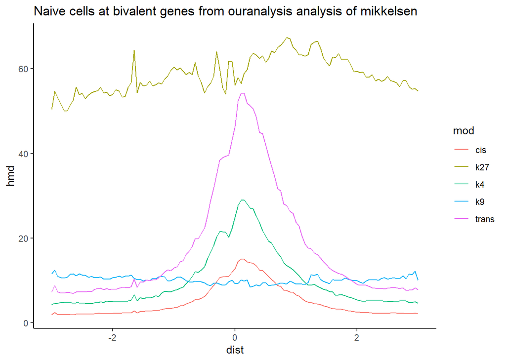

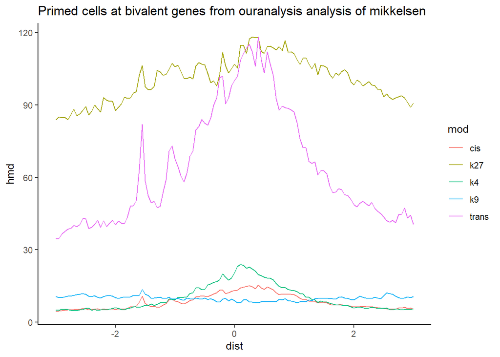

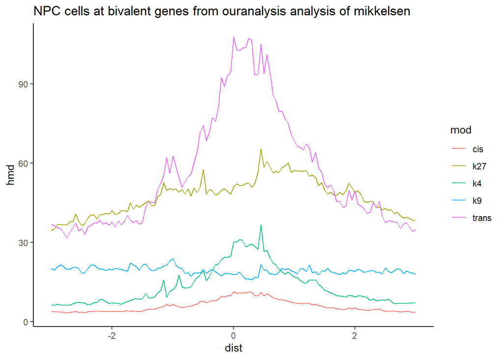

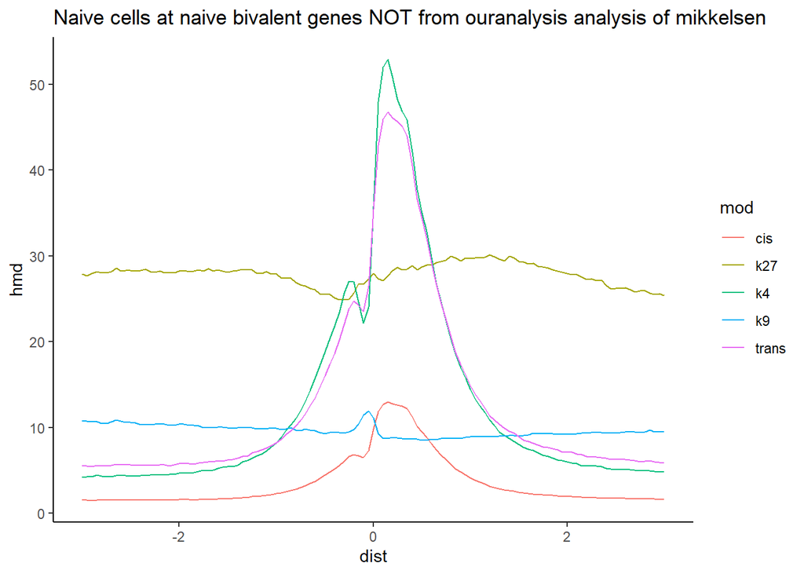

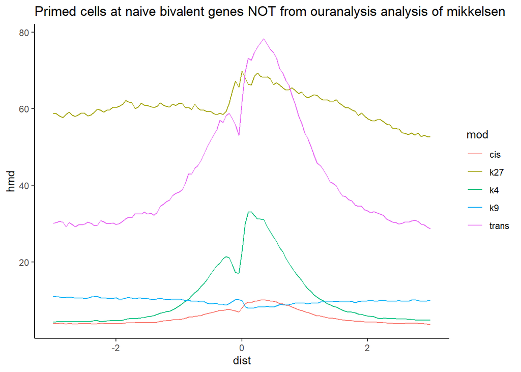

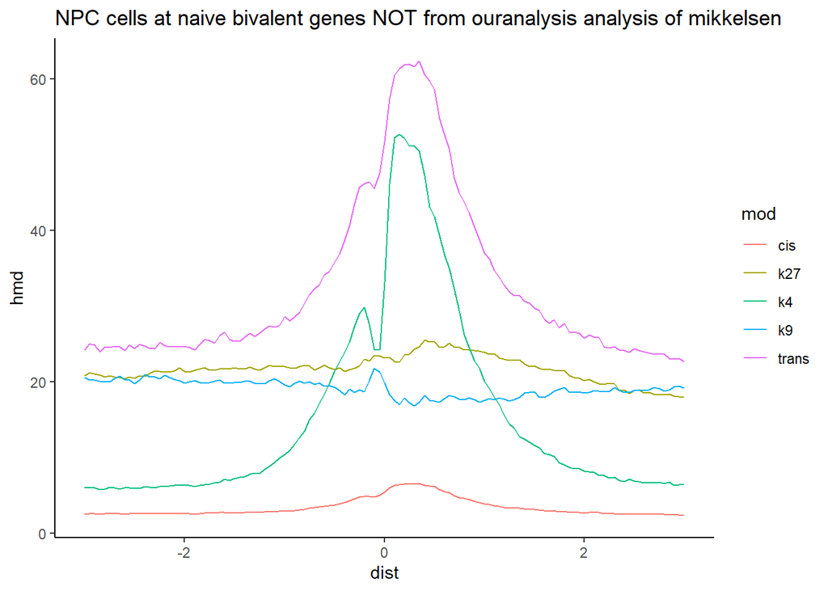

```
## [1] "mas"
##      [,1]  [,2]
## [1,] 7235  3839
## [2,] 8532 37486
## [1] 0
```

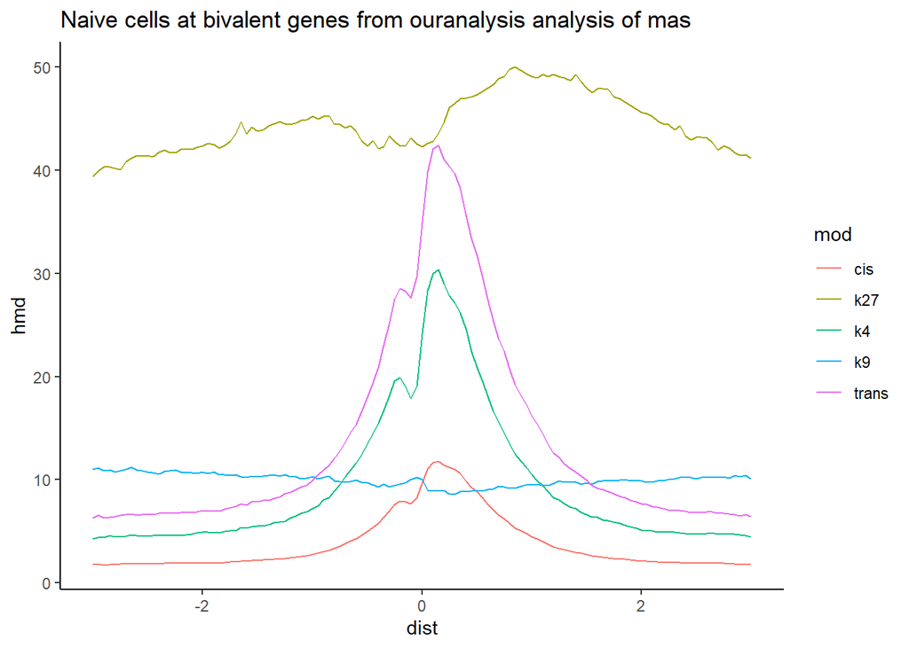

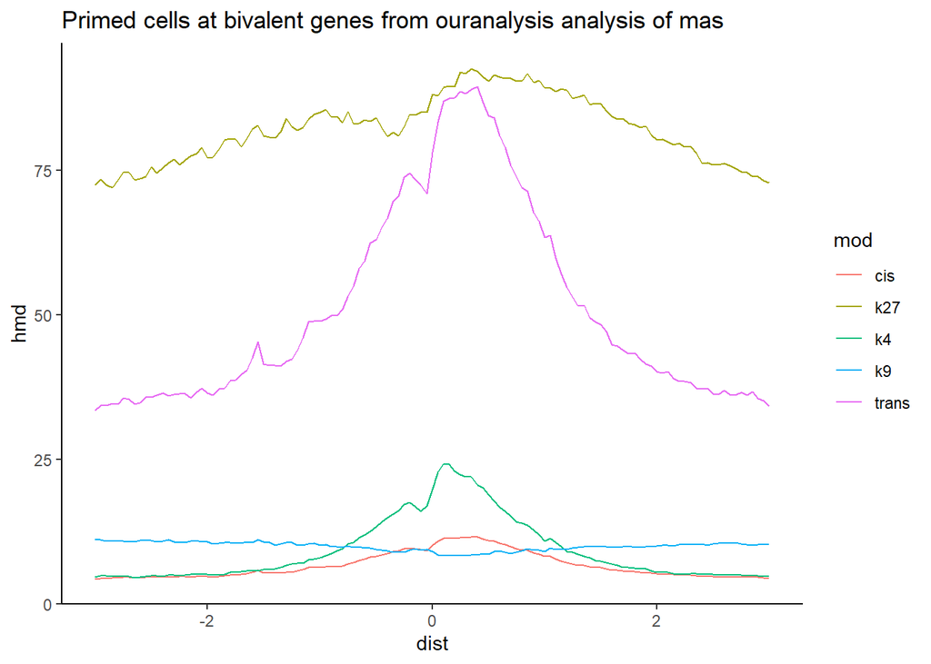

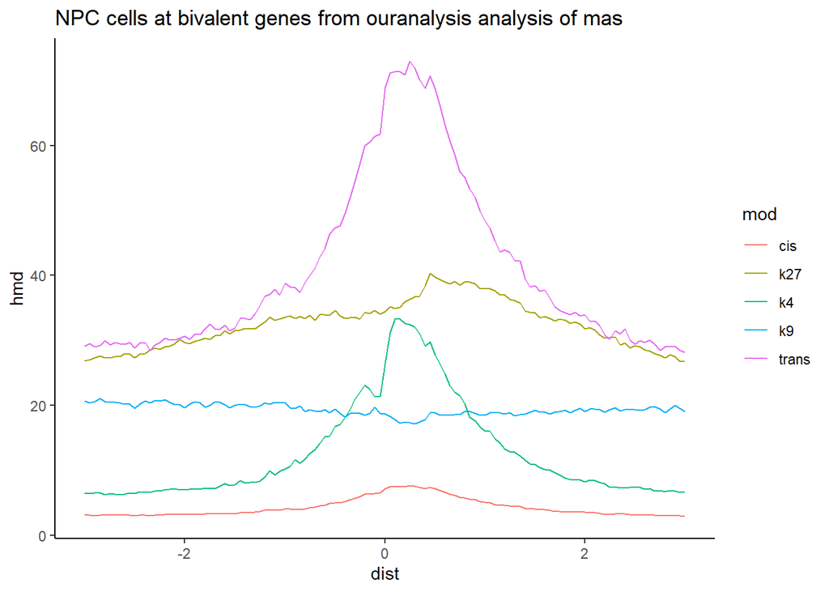

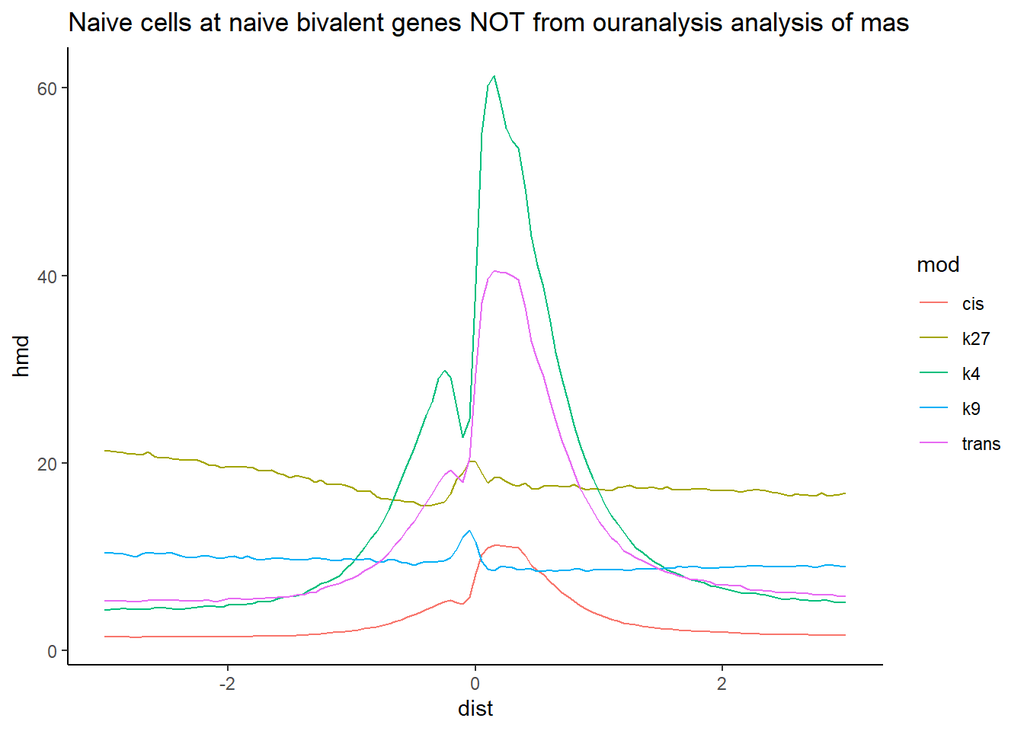

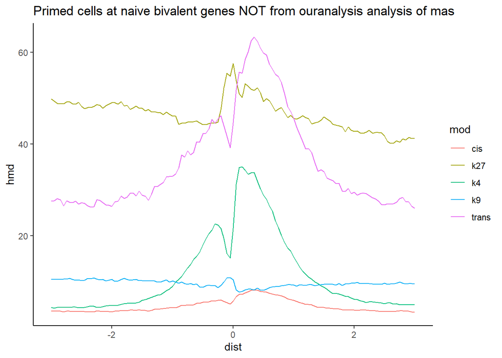

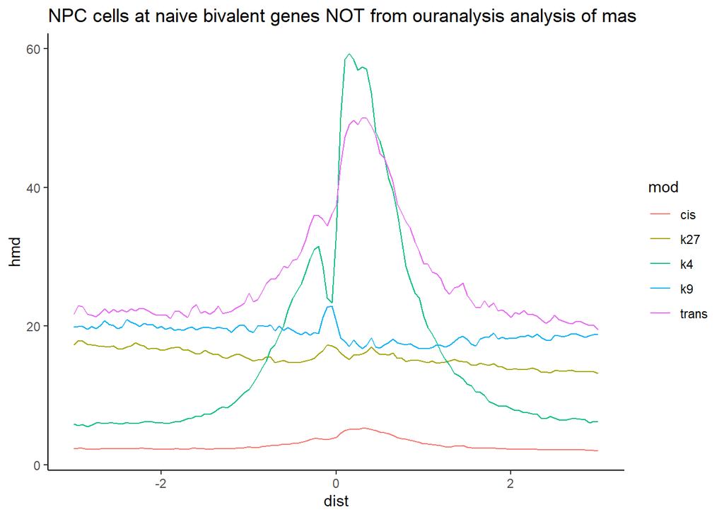

```
## [1] "xiao"
##       [,1]  [,2]
## [1,]  3787  1269
## [2,] 11980 33160
## [1] 0
```

[6 more figures not shown]

```r
ouranalysis = list()
ouranalysis$mikkelsen = read.table("full_genes/Bivalent_refseq_Mikkelsen.bed", stringsAsFactors = F, header = F)$V4
ouranalysis$mas = read.table("full_genes/Bivalent_refseq_Mas.bed", stringsAsFactors = F, header = F)$V4
ouranalysis$xiao = read.table("full_genes/Bivalent_refseq_Xiao.bed", stringsAsFactors = F, header = F)$V4

ouranalysis_fisher = list()

for (i in names(ouranalysis))
{
  in_both = bivalent_genes_25$naive %in% ouranalysis[[i]] %>% sum
  only_naive = setdiff(bivalent_genes_25$naive[bivalent_genes_25$naive %in% consensusGenes], ouranalysis[[i]]) %>% length
  only_ouranalysis = setdiff(ouranalysis[[i]], bivalent_genes_25$naive[bivalent_genes_25$naive %in% consensusGenes]) %>% length
  in_neither = length(consensusGenes) - only_naive - only_ouranalysis + in_both
  print(i)
  print(matrix(c(in_both, only_naive, only_ouranalysis, in_neither), nr = 2))
  ouranalysis_fisher[[i]] = fisher.test(matrix(c(in_both, only_naive, only_ouranalysis, in_neither), nr = 2), alternative = "greater")
  print(phyper(in_both, length(bivalent_genes_25$naive[bivalent_genes_25$naive %in% consensusGenes]), length(setdiff(consensusGenes, bivalent_genes_25$naive)), length(ouranalysis[[i]]), lower.tail = FALSE))

  metagene_plot(metagene(naive, tss_range, ouranalysis[[i]]), title = paste0("Naive cells at bivalent genes from ouranalysis analysis of ", i))
  metagene_plot(metagene(primed, tss_range, ouranalysis[[i]]), title = paste0("Primed cells at bivalent genes from ouranalysis analysis of ", i))
  metagene_plot(metagene(npc, tss_range, ouranalysis[[i]]), title = paste0("NPC cells at bivalent genes from ouranalysis analysis of ", i))

  naive_not_i = setdiff(bivalent_genes_25$naive[bivalent_genes_25$naive %in% consensusGenes], ouranalysis[[i]])
  metagene_plot(metagene(naive, tss_range, naive_not_i), title = paste0("Naive cells at naive bivalent genes NOT from ouranalysis analysis of ", i))
  metagene_plot(metagene(primed, tss_range, naive_not_i), title = paste0("Primed cells at naive bivalent genes NOT from ouranalysis analysis of ", i))
  metagene_plot(metagene(npc, tss_range, naive_not_i), title = paste0("NPC cells at naive bivalent genes NOT from ouranalysis analysis of ", i))

  rm(in_both, in_neither, only_ouranalysis, only_naive, naive_not_i)
}
```

Overwhelmingly, it seems clear that everyone else only looked at the most strongly H3K27me3-dominant genes by the ouranalysis reanalysis. Now we will look using our metric, where we only consider it if there is both H3K4me3 and H3K27me3 peak overlapping the +1/+2 nucleosomes.

```
## [1] "mikkelsen"
##       [,1]  [,2]
## [1,]  1171   164
## [2,] 14596 29033
## [1] 0
```

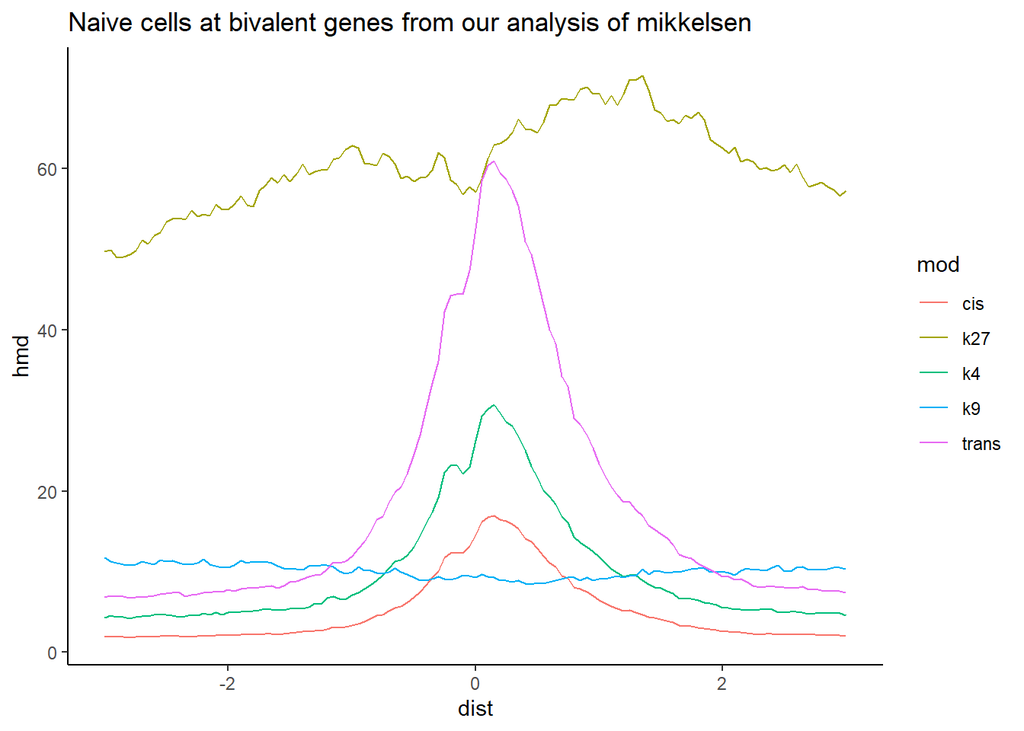

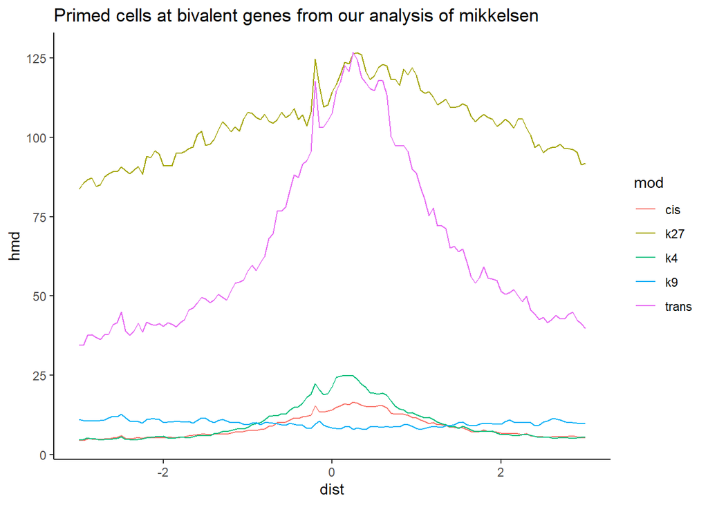

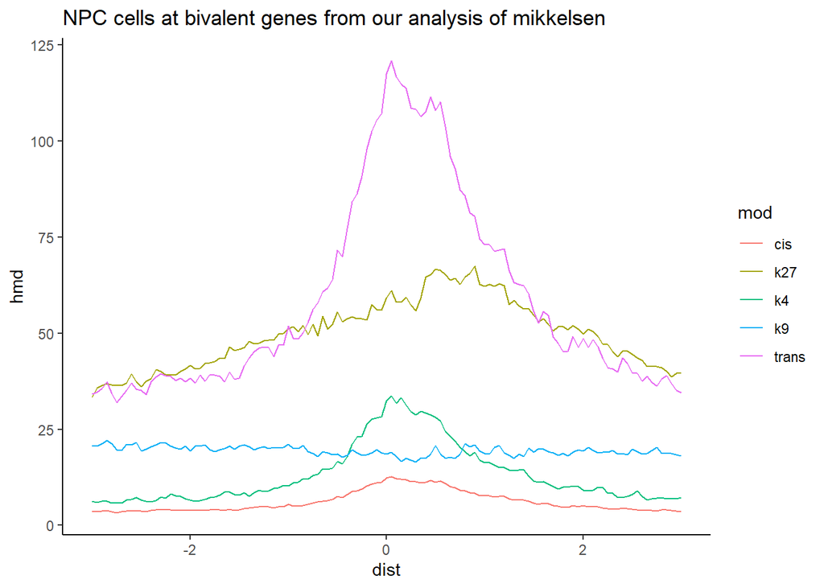

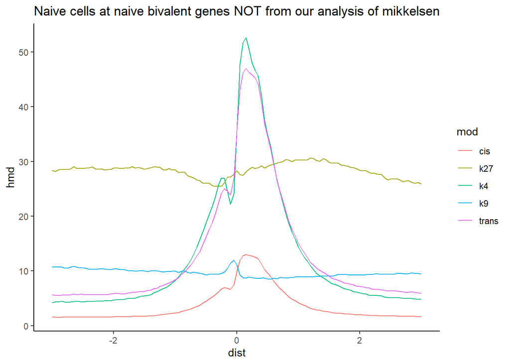

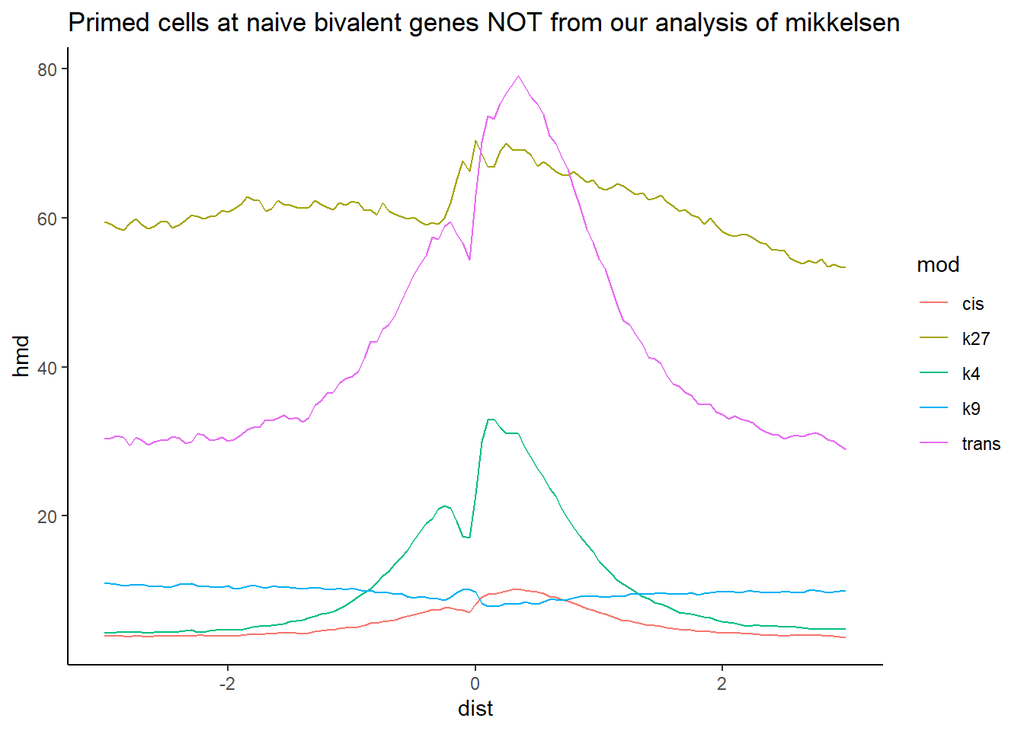

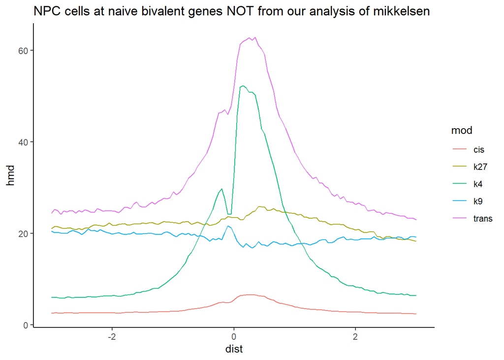

```
## [1] "mas"
##       [,1]  [,2]
## [1,]  5126  1744
## [2,] 10641 35363
## [1] 0
```

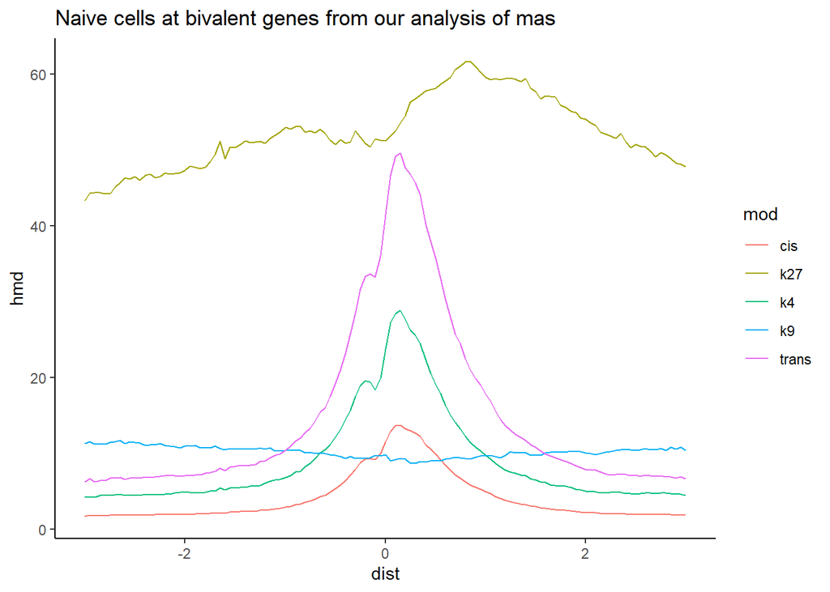

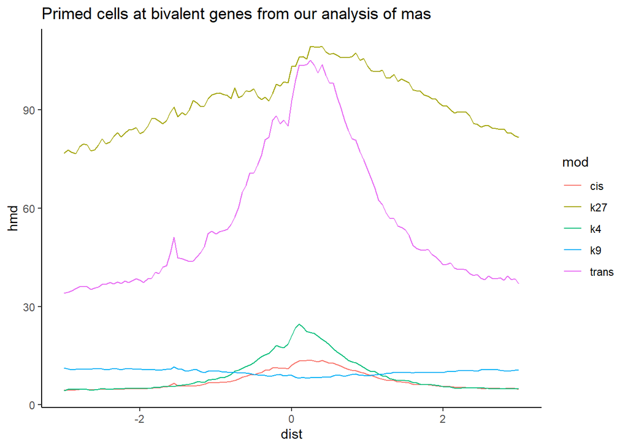

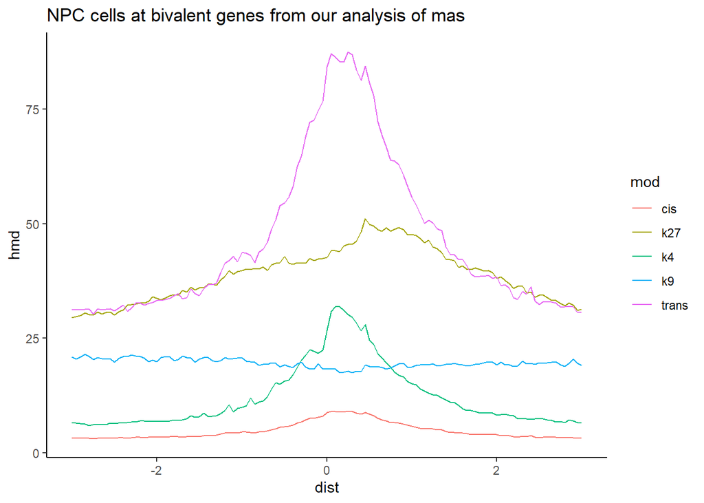

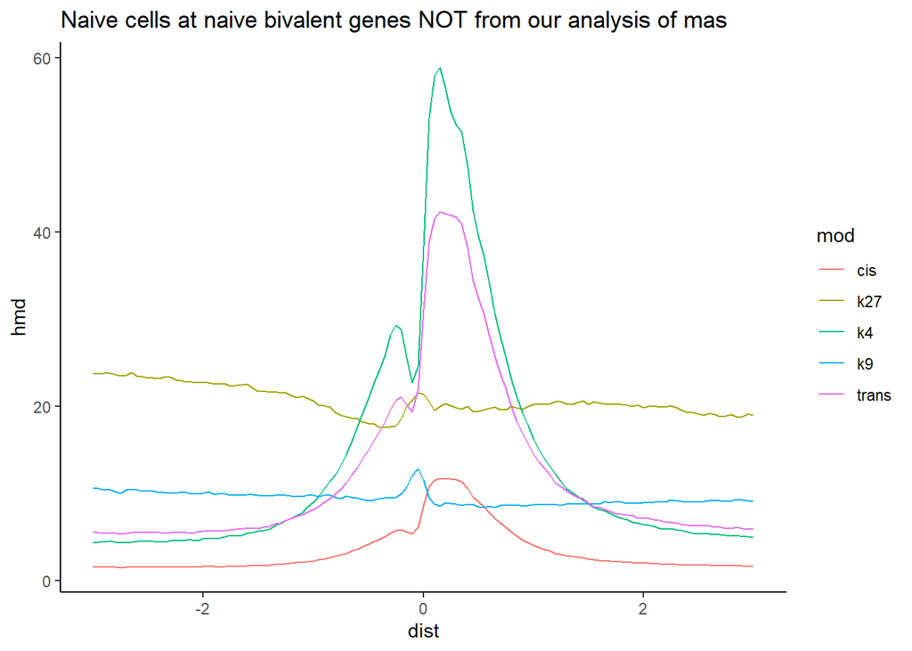

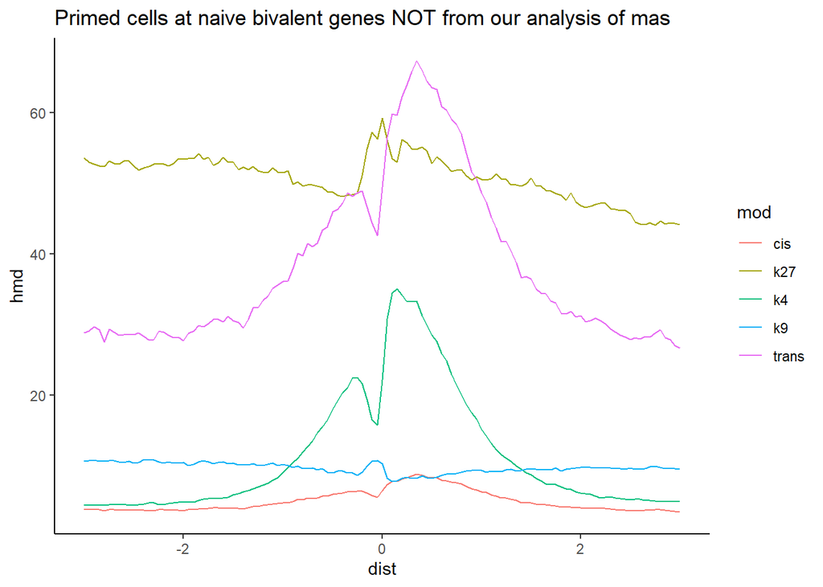

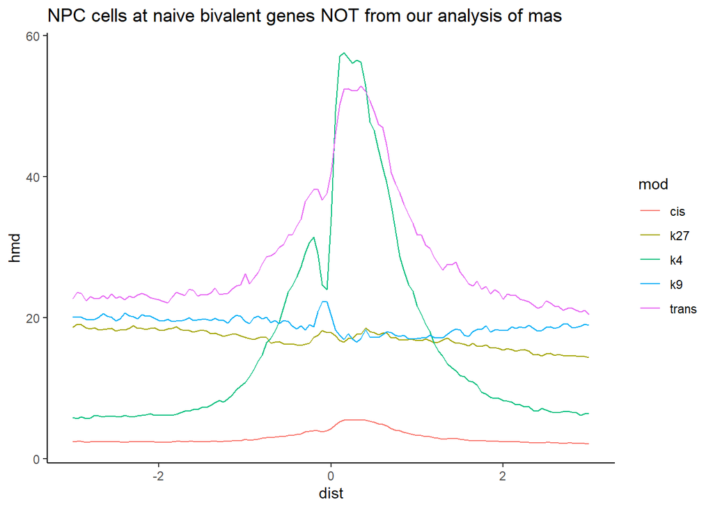

```
## [1] "xiao"
##       [,1]  [,2]
## [1,]  2987   659
## [2,] 12780 32170
## [1] 0
```

[6 more figures not shown]

```r
ouranalysis = list()
ouranalysis$mikkelsen = read.table("refseq_promoter/Bivalent_refseq_promoter_Mikkelsen.tab", stringsAsFactors = F, header = F)$V4
ouranalysis$mas = read.table("refseq_promoter/Bivalent_refseq_promoter_Mas.tab", stringsAsFactors = F, header = F)$V4
ouranalysis$xiao = read.table("refseq_promoter/Bivalent_refseq_promoter_Xiao.tab", stringsAsFactors = F, header = F)$V4

ouranalysis_fisher = list()

for (i in names(ouranalysis))
{
  in_both = bivalent_genes_25$naive %in% ouranalysis[[i]] %>% sum
  only_naive = setdiff(bivalent_genes_25$naive[bivalent_genes_25$naive %in% consensusGenes], ouranalysis[[i]]) %>% length
  only_ouranalysis = setdiff(ouranalysis[[i]], bivalent_genes_25$naive[bivalent_genes_25$naive %in% consensusGenes]) %>% length
  in_neither = length(consensusGenes) - only_naive - only_ouranalysis + in_both
  print(i)
  print(matrix(c(in_both, only_naive, only_ouranalysis, in_neither), nr = 2))
  ouranalysis_fisher[[i]] = fisher.test(matrix(c(in_both, only_naive, only_ouranalysis, in_neither), nr = 2), alternative = "greater")
  print(phyper(in_both, length(bivalent_genes_25$naive[bivalent_genes_25$naive %in% consensusGenes]), length(setdiff(consensusGenes, bivalent_genes_25$naive)), length(ouranalysis[[i]]), lower.tail = FALSE))

  metagene_plot(metagene(naive, tss_range, ouranalysis[[i]]), title = paste0("Naive cells at bivalent genes from our analysis of ", i))
  metagene_plot(metagene(primed, tss_range, ouranalysis[[i]]), title = paste0("Primed cells at bivalent genes from our analysis of ", i))
  metagene_plot(metagene(npc, tss_range, ouranalysis[[i]]), title = paste0("NPC cells at bivalent genes from our analysis of ", i))

  naive_not_i = setdiff(bivalent_genes_25$naive[bivalent_genes_25$naive %in% consensusGenes], ouranalysis[[i]])
  metagene_plot(metagene(naive, tss_range, naive_not_i), title = paste0("Naive cells at naive bivalent genes NOT from our analysis of ", i))
  metagene_plot(metagene(primed, tss_range, naive_not_i), title = paste0("Primed cells at naive bivalent genes NOT from our analysis of ", i))
  metagene_plot(metagene(npc, tss_range, naive_not_i), title = paste0("NPC cells at naive bivalent genes NOT from our analysis of ", i))

  rm(in_both, in_neither, only_ouranalysis, only_naive, naive_not_i)
}
```

Again, they’re just looking at the H3K27me3-dominated class of genes.